# Introduction to the ProbBayes Package

Jim Albert

3/6/2020

### Introduction

The `ProbBayes` package was written to accompany the text *Probability and Bayesian Modeling* by Jim Albert and Jingchen Hu. The package includes a number of functions to illustrate Bayesian computations described in the text. In addition, `ProbBayes` contains all datasets used in the examples and exercises. The purpose of this document to provide an overview of the functions contained in the package.

### Installing ProbBayes

The `ProbBayes` package is available on CRAN. The package is installed by use of the `install.packages()` function.

```
install.packages("ProbBayes")
```

To load the package, use the `library()` function.

```r
library(ProbBayes)
```

(Note: The `ProbBayes` package depends on the `LearnBayes`, `ggplot2`, `gridExtra`, and `shiny` packages. It may be necessary to also install these prerequisite packages for `ProbBayes` to correctly install.)

### Datasets

All datsets mentioned in *Probability and Bayesian Modeling* are contained in the `ProbBayes` package. For example, the dataset `pt99price.csv` contains the point prices of 0.99 carat diamonds in Exercise 16 of Chapter 8. This data is contained in the data framew `` pt99price`` in ``ProbBayes```.

```r
head(pt99price)
```

```
##   diamond    price
## 1       1 28.39394
## 2       2 28.40404
## 3       3 29.78788
## 4       4 33.70707
## 5       5 36.29293
## 6       6 40.42424
```

### Functions in Chapter 3 - Bayes’ Rule

#### Learning About a Spinner

This chapter introduces Bayes’ rule by use of a spinner example. Suppose there are four possible spinners defined by four vectors. The length of a vector corresponds to the number of areas and the values are proportional to the areas.

```r
s1 <- c(2, 2, 2, 2)
s2 <- c(4, 1, 1, 2)
s3 <- c(2, 4, 2)
s4 <- c(1, 3, 3, 1)
```

We can see these spinners by use of the `many_spinner_plots()` function.

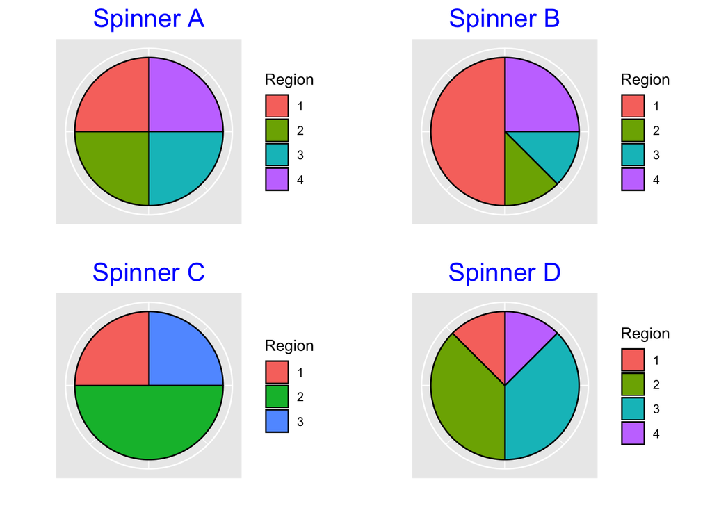

```r
many_spinner_plots(list(s1, s2, s3, s4))
```

Initially, suppose you have little knowledge about the actual spinner and so you place a uniform prior on these spinners. We construct a data frame with the four models and the associated prior probabilities.

```r
(bayes_table <- data.frame(Model =
                paste("Spinner", c("A", "B", "C", "D")),
                Prior = c(1, 1, 1, 1) / 4))
```

```
##       Model Prior
## 1 Spinner A  0.25
## 2 Spinner B  0.25
## 3 Spinner C  0.25
## 4 Spinner D  0.25
```

Suppose a spinner is chosen at random and the outcome is “1”. The likelihood is the chance of observing “1” for each spinner.

```r
library(dplyr)
(bayes_table %>%
  mutate(Likelihood = c(1/4, 1/2, 1/4, 1/8)) ->
bayes_table)
```

```
##       Model Prior Likelihood
## 1 Spinner A  0.25      0.250
## 2 Spinner B  0.25      0.500
## 3 Spinner C  0.25      0.250
## 4 Spinner D  0.25      0.125
```

The `bayesian_crank()` function will update the probabilities given that the spinner landed “1”.

```r
(bayes_table <- bayesian_crank(bayes_table))
```

```
##       Model Prior Likelihood Product Posterior
## 1 Spinner A  0.25      0.250 0.06250 0.2222222
## 2 Spinner B  0.25      0.500 0.12500 0.4444444
## 3 Spinner C  0.25      0.250 0.06250 0.2222222
## 4 Spinner D  0.25      0.125 0.03125 0.1111111
```

The `prior_post_plot()` plots the prior and posterior probabilities of the spinners. We see that it is most likely that the unknown spinner is Spinner B.

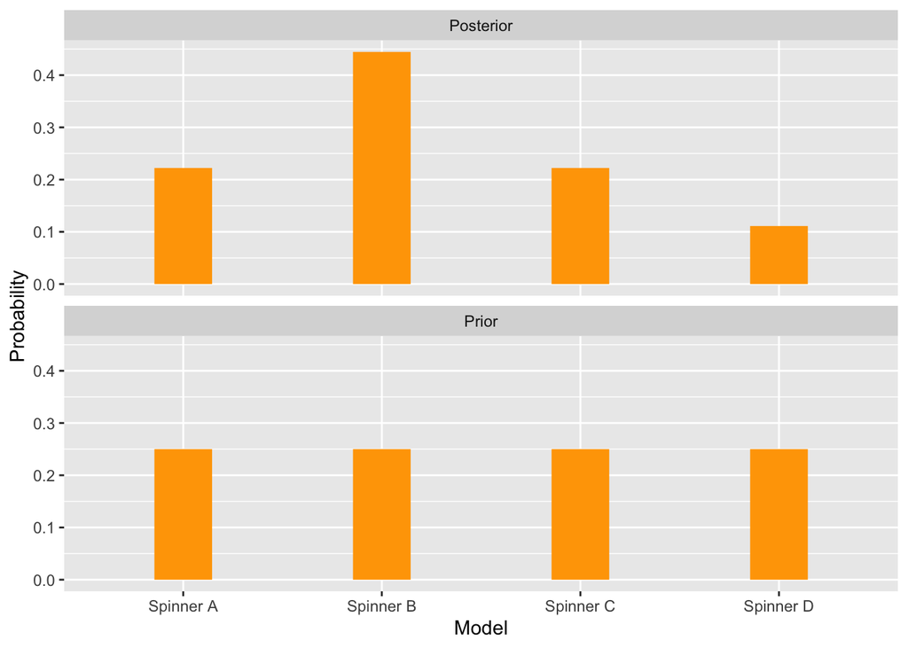

```r
prior_post_plot(bayes_table)
```

### Functions for Chapter 7: Learning about a Binomial Probability

#### Using a Discrete Prior

We introduce Bayesian thinking about a proportion using a discrete prior. Suppose you are interested in estimating the proportion $p$ of coffee drinkers on campus and your prior on $p$ is uniform on the values $p$ = 0.1, 0.2, …, 0.9. You take a sample of 20 students and you find 12 coffee drinkers. What have you learned about $p$?

Construct a data frame with your prior.

```r
(df <- data.frame(p = seq(0.1, 0.9, by = 0.1),
                 Prior = rep(1/9, 9)))
```

```
##     p     Prior
## 1 0.1 0.1111111
## 2 0.2 0.1111111
## 3 0.3 0.1111111
## 4 0.4 0.1111111
## 5 0.5 0.1111111
## 6 0.6 0.1111111
## 7 0.7 0.1111111
## 8 0.8 0.1111111
## 9 0.9 0.1111111
```

The likelihood is the binomial probability of 12 successes out of 20 when the probability of success is $p$.

```r
(df %>%
  mutate(Likelihood = dbinom(12, size = 20, prob = p)) -> df)
```

```
##     p     Prior   Likelihood
## 1 0.1 0.1111111 5.422595e-08
## 2 0.2 0.1111111 8.656592e-05
## 3 0.3 0.1111111 3.859282e-03
## 4 0.4 0.1111111 3.549744e-02
## 5 0.5 0.1111111 1.201344e-01
## 6 0.6 0.1111111 1.797058e-01
## 7 0.7 0.1111111 1.143967e-01
## 8 0.8 0.1111111 2.216088e-02
## 9 0.9 0.1111111 3.557765e-04
```

Update the probabilities using the `bayesian_crank()` function.

```r
(df <- bayesian_crank(df))
```

```
##     p     Prior   Likelihood      Product    Posterior
## 1 0.1 0.1111111 5.422595e-08 6.025106e-09 1.138730e-07
## 2 0.2 0.1111111 8.656592e-05 9.618436e-06 1.817860e-04
## 3 0.3 0.1111111 3.859282e-03 4.288091e-04 8.104383e-03
## 4 0.4 0.1111111 3.549744e-02 3.944160e-03 7.454362e-02
## 5 0.5 0.1111111 1.201344e-01 1.334826e-02 2.522788e-01
## 6 0.6 0.1111111 1.797058e-01 1.996731e-02 3.773771e-01
## 7 0.7 0.1111111 1.143967e-01 1.271075e-02 2.402299e-01
## 8 0.8 0.1111111 2.216088e-02 2.462320e-03 4.653722e-02
## 9 0.9 0.1111111 3.557765e-04 3.953072e-05 7.471206e-04
```

Show the prior and posterior for $p$. We see that it is very likely that $p$ is 0.5, 0.6, or 0.7.

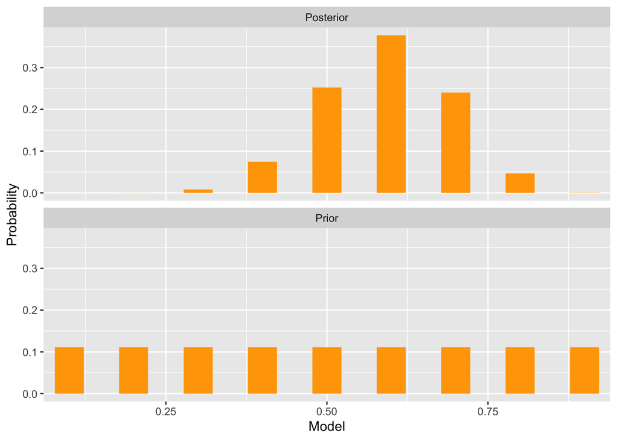

```r
prior_post_plot(df)
```

#### Using a Beta Prior

Using the same example, suppose you want to use a beta prior to model your beliefs about $p$, the proportion of coffee drinkers on campus. Your median for $p$ is 0.40 and you are 90% sure that $p$ is smaller than 0.55. The `beta.select()` function will find the shape parameters of the beta prior that matches these statements.

```r
(ab <- beta.select(list(p = 0.5, x = 0.4),
                   list(p = 0.9, x = 0.55)))
```

```
## [1]  7.53 11.13
```

(You can graphically find the beta parameters to match statements of the 50th and 90th percentiles by use of a Shiny app accessed by the `ChooseBeta()` function.)

We observed 12 coffee drinkers and 8 non-coffee drinkers. We update the beta parameters of the beta posterior.

```r
(ab_new <- ab + c(12, 8))
```

```
## [1] 19.53 19.13
```

The `beta_prior_post()` function shows the prior and posterior beta functions.

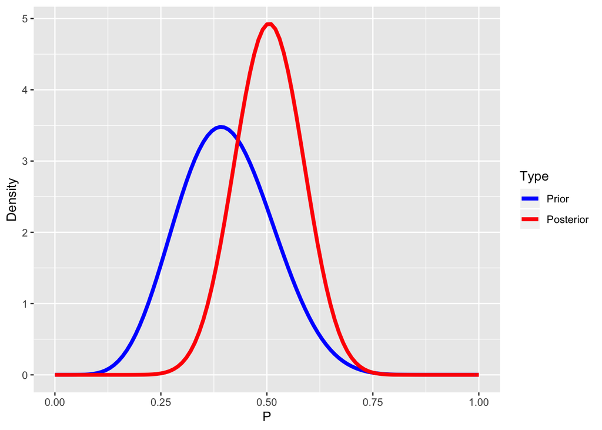

```r
beta_prior_post(ab, ab_new)
```

There are several functions `beta_area()`, `beta_interval()`, `beta_quantile()` to summarize the beta posterior.

To illustrate, we use the `beta_interval()` to construct a 90% interval for $p$.

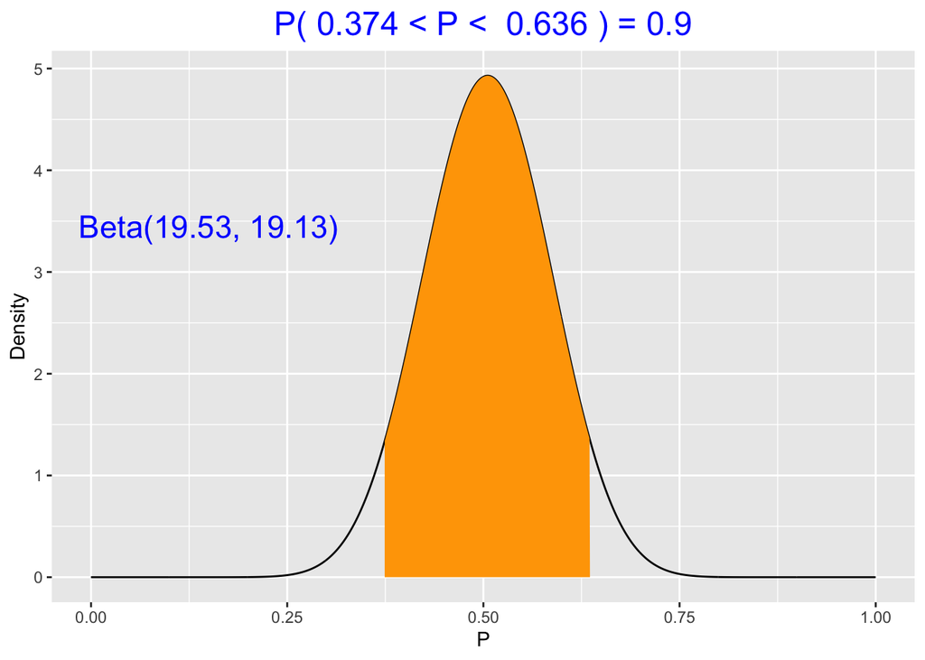

```r
beta_interval(0.90, ab_new)
```

### Functions for Chapter 8: Learning about a Normal Mean

#### Using a normal prior

Suppose a dietician wishes to learn about the mean weight gain $\mu$ of freshmen college students in the first month of college. His best guess apriori at $\mu$ is 3 lbs and he is 90% sure that $\mu$ is smaller than 5 lbs.

We find a matching normal prior by use of the `normal.select()` function.

```r
(normal_prior <- normal.select(list(p = .5, x = 3),
                              list(p = .9, x = 5)))
```

```
## $mu
## [1] 3
##
## $sigma
## [1] 1.560608
```

We see that a N(3, 1.56) prior matches his beliefs.

Suppose a sample of students gives $\bar y = 2$ with a standard error of $se = 0.5$. One can find the parameters of the normal posterior by the `normal_update()` function.

```r
prior <- c(3, 1.56)
data <- c(2, 0.5)
normal_update(prior, data, teach = TRUE)
```

```
##        Type     Mean Precision Stand_Dev
## 1     Prior 3.000000 0.4109139 1.5600000
## 2      Data 2.000000 4.0000000 0.5000000
## 3 Posterior 2.093158 4.4109139 0.4761411
```

We see the posterior for $\mu$ is N(2.09, 0.48).

The functions `normal_area()`, `normal_interval()` and `normal_quantile()` are helpful for computing various summaries of the normal posterior.

What is the posterior probability that $\mu$ is between 1 and 3 lbs?

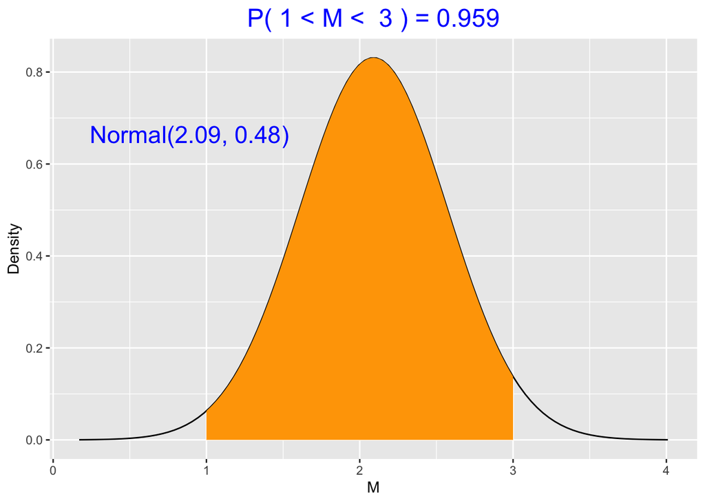

```r
normal_area(1, 3, c(2.09, 0.48))
```

### Functions for Chapter 9: Introduction to MCMC

There are several functions `random_walk()`, `metropolis()`, `gibbs_discrete()`, `gibbs_normal()`, and `gibbs_betabin()` that are discussed in the text.

#### Using the Metropolis algorithm

We illustrate the use of `metropolis()` to simulate from a real-valued posterior of a single parameter.

In the Cauchy-Normal problem discussed in Section 9.4, suppose $\mu$ is the mean monthly snowfall and we assign $\mu$ a Cauchy prior with location 10 and scale 2. We observe some data – the sample mean is $\bar y = 26.78$ inches with corresponding standard error of 3.24 inches.

I program the log posterior:

```r
cn_logpost <- function(mu, loc, scale, ybar, se){
  dcauchy(mu, loc, scale, log = TRUE) +
    dnorm(ybar, mu, se, log = TRUE)
}
```

I use metropolis sampling where (1) the starting value is 10, (2) the width of the proposal density is 20, and I take 5000 interations.

```r
post <- metropolis(cn_logpost, 10, 20, 5000,
                10, 2, 26.78, 3.24)
```

We check the acceptance rate of the algorithm.

```r
post$accept_rate
```

```
## [1] 0.2688
```

By using the `coda` package, we display a trace plot and density plot of the simulated draws.

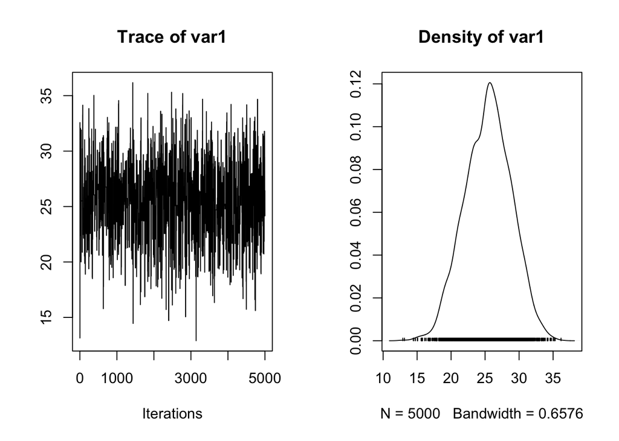

```r
library(coda)
plot(mcmc(post$S))
```

We use the `coda` package to get posterior summaries.

```r
summary(mcmc(post$S))
```

```
##
## Iterations = 1:5000
## Thinning interval = 1
## Number of chains = 1
## Sample size per chain = 5000
##
## 1. Empirical mean and standard deviation for each variable,
##    plus standard error of the mean:
##
##           Mean             SD       Naive SE Time-series SE
##       25.44596        3.40757        0.04819        0.10744
##
## 2. Quantiles for each variable:
##
##  2.5%   25%   50%   75% 97.5%
## 18.79 23.19 25.51 27.85 31.79
```

### Functions for Chapter 10 Hierarchical Modeling

#### Beta-binomial modeling

Section 10.3 illustrates the use of hierarchical model where

- $y_j \sim$ binomial($n_j, p_j$) and $p_j \sim$ beta($a, b$), $i = 1, ..., N$, where $a = \eta \mu$, $b = \eta (1 - \mu)$.
- The hyperparameters are given the priors $\mu \sim Beta(a, b)$ and $\log \eta \sim$ Logistic($\log n^*, 1$).

We illustrate fitting this model on the famous Efron and Morris’ baseball dataset stored in the `pscl` package.

```r
library(pscl)
(select(EfronMorris, name, r) %>%
      mutate(n = 45) -> d)
```

```
##                name  r  n
## 1  Roberto Clemente 18 45
## 2    Frank Robinson 17 45
## 3      Frank Howard 16 45
## 4     Jay Johnstone 15 45
## 5         Ken Berry 14 45
## 6       Jim Spencer 14 45
## 7     Don Kessinger 13 45
## 8     Luis Alvarado 12 45
## 9         Ron Santo 11 45
## 10      Ron Swoboda 11 45
## 11        Del Unser 10 45
## 12   Billy Williams 10 45
## 13     George Scott 10 45
## 14  Rico Petrocelli 10 45
## 15  Ellie Rodriguez 10 45
## 16  Bert Campaneris  9 45
## 17   Thurman Munson  8 45
## 18        Max Alvis  7 45
```

We store the data and parameters of the hyperparameter distribution in the list `the_data`.

```r
the_data <- list(y = d$r, n = d$n, N = 18,
                 "mua" = 1, "mub" = 1,
                 "logn" = log(45))
```

The JAGS script for this model is stored in the function `JAGS_script()` with the “beta_binomial” argument. We fit this model by MCMC using the `runs.jags()` function in the `runjags` package.

```r
library(runjags)
posterior <- run.jags(JAGS_script("beta_binomial"),
                          n.chains = 1,
                          data = the_data,
                monitor = c("p", "mu", "eta"),
                          adapt = 1000,
                          burnin = 10000,
                          sample = 20000)
```

```
## Compiling rjags model...
## Calling the simulation using the rjags method...
## Adapting the model for 1000 iterations...
## Burning in the model for 10000 iterations...
## Running the model for 20000 iterations...
## Simulation complete
## Calculating summary statistics...
## Finished running the simulation
```

Posterior summaries of the parameters $p_1, ..., p_N, \mu, \eta$ are obtained by the `print()` method.

```r
print(posterior, digits = 3)
```

```
##
## JAGS model summary statistics from 20000 samples (adapt+burnin = 11000):
##
##       Lower95 Median Upper95  Mean     SD Mode    MCerr MC%ofSD SSeff  AC.10
## p[1]    0.226  0.293   0.388 0.299 0.0427   --   0.0012     2.8  1274  0.187
## p[2]    0.221  0.289   0.378 0.294 0.0403   -- 0.000993     2.5  1648  0.179
## p[3]    0.215  0.284   0.366 0.288 0.0385   -- 0.000852     2.2  2039  0.155
## p[4]    0.216   0.28   0.367 0.284 0.0383   -- 0.000894     2.3  1832  0.112
## p[5]    0.206  0.275   0.354 0.278 0.0368   -- 0.000687     1.9  2863 0.0854
## p[6]    0.209  0.274   0.353 0.277  0.036   -- 0.000685     1.9  2764 0.0757
## p[7]    0.205   0.27   0.349 0.272 0.0358   -- 0.000601     1.7  3547 0.0772
## p[8]    0.195  0.265   0.334 0.266 0.0346   -- 0.000581     1.7  3532 0.0629
## p[9]    0.191  0.261   0.334 0.262 0.0352   -- 0.000629     1.8  3120 0.0871
## p[10]   0.189  0.262   0.331 0.262 0.0355   -- 0.000679     1.9  2729 0.0712
## p[11]   0.185  0.257   0.325 0.257 0.0349   -- 0.000723     2.1  2331 0.0954
## p[12]   0.183  0.257   0.322 0.256 0.0349   -- 0.000658     1.9  2818 0.0894
## p[13]   0.186  0.257   0.327 0.256 0.0347   -- 0.000621     1.8  3118 0.0785
## p[14]    0.18  0.257   0.325 0.256 0.0357   -- 0.000619     1.7  3323 0.0795
## p[15]   0.182  0.257   0.321 0.256 0.0351   -- 0.000585     1.7  3603 0.0628
## p[16]   0.175  0.252   0.317  0.25 0.0357   -- 0.000744     2.1  2302  0.128
## p[17]   0.167  0.248   0.314 0.245  0.037   -- 0.000813     2.2  2070  0.126
## p[18]   0.161  0.242   0.306 0.239 0.0371   -- 0.000955     2.6  1511  0.169
## mu      0.232  0.267   0.303 0.267 0.0181   --  0.00052     2.9  1216  0.302
## eta      13.2    158    1724   663   4177   --      283     6.8   217  0.544
##
##       psrf
## p[1]    --
## p[2]    --
## p[3]    --
## p[4]    --
## p[5]    --
## p[6]    --
## p[7]    --
## p[8]    --
## p[9]    --
## p[10]   --
## p[11]   --
## p[12]   --
## p[13]   --
## p[14]   --
## p[15]   --
## p[16]   --
## p[17]   --
## p[18]   --
## mu      --
## eta     --
##
## Total time taken: 2.7 seconds
```